# Reproducible Research Course Project 1

Ashok Patil

July 31, 2016

First the global options of echo = T are set with the following code chunk so that the code is visible to peer evaluators all the time.

```r
library(knitr)
opts_chunk$set(echo = TRUE)
```

## Loading and preprocessing the data

The code chunk for downloading data online.

```r
temp <- tempfile()
download.file(url = "https://d396qusza40orc.cloudfront.net/repdata%2Fdata%2Factivity.zip", temp)
proj1 <- unz(temp, "activity.csv")
activity <- read.csv(proj1, header = T, stringsAsFactors = FALSE)
unlink(temp)
```

A look at the data

```r
library(dplyr)
str(activity)
```

```
## 'data.frame':    17568 obs. of  3 variables:
##  $ steps   : int  NA NA NA NA NA NA NA NA NA NA ...
##  $ date    : chr  "2012-10-01" "2012-10-01" "2012-10-01" "2012-10-01" ...
##  $ interval: int  0 5 10 15 20 25 30 35 40 45 ...
```

```r
summary(activity)
```

```
##      steps            date              interval
##  Min.   :  0.00   Length:17568       Min.   :   0.0
##  1st Qu.:  0.00   Class :character   1st Qu.: 588.8
##  Median :  0.00   Mode  :character   Median :1177.5
##  Mean   : 37.38                      Mean   :1177.5
##  3rd Qu.: 12.00                      3rd Qu.:1766.2
##  Max.   :806.00                      Max.   :2355.0
##  NA's   :2304
```

```r
glimpse(activity)
```

```
## Observations: 17,568
## Variables: 3
## $ steps    <int> NA, NA, NA, NA, NA, NA, NA, NA, NA, NA, NA, NA, NA, N...
## $ date     <chr> "2012-10-01", "2012-10-01", "2012-10-01", "2012-10-01...
## $ interval <int> 0, 5, 10, 15, 20, 25, 30, 35, 40, 45, 50, 55, 100, 10...
```

## What is mean total number of steps taken per day?

### For this part of the assignment, the missing values in the dataset are ignored.

1. The total number of steps taken per day The following code chunck produces the total number of steps taken per day.

```r
total.steps <- activity %>% group_by(date) %>% filter(!is.na(steps)) %>% summarize(steps.sum = sum(steps, na.rm = F))

total.steps
```

```
## # A tibble: 53 x 2
##          date steps.sum
##         <chr>     <int>
## 1  2012-10-02       126
## 2  2012-10-03     11352
## 3  2012-10-04     12116
## 4  2012-10-05     13294
## 5  2012-10-06     15420
## 6  2012-10-07     11015
## 7  2012-10-09     12811
## 8  2012-10-10      9900
## 9  2012-10-11     10304
## 10 2012-10-12     17382
## # ... with 43 more rows
```

2. Histogram of the total number of steps taken each day

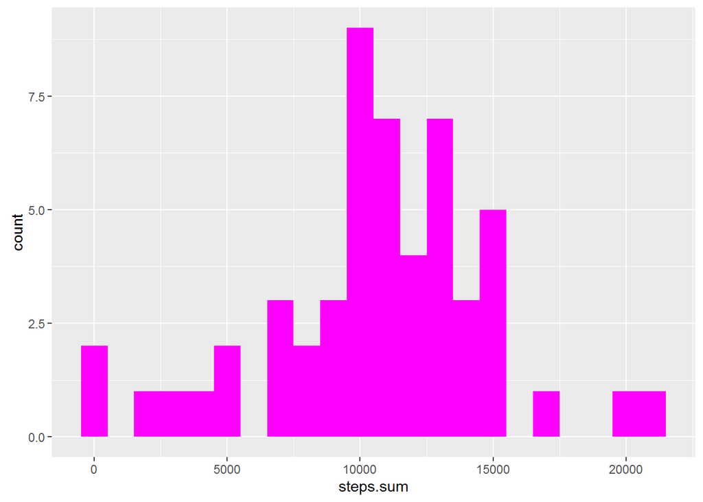

```r
library(ggplot2)
ggplot(data = total.steps, aes(x = steps.sum)) + geom_histogram(fill = "#FF00FF",binwidth = 1000)
```

```r
mean.steps.day <- aggregate(steps ~ date, data = activity, FUN = mean)
median.steps.day <- aggregate(steps ~ date, data = activity, FUN = median)
#mean.steps <- mean(total.steps$steps.sum)
#mean.steps
mean.steps.day
```

```
##          date      steps
## 1  2012-10-02  0.4375000
## 2  2012-10-03 39.4166667
## 3  2012-10-04 42.0694444
## 4  2012-10-05 46.1597222
## 5  2012-10-06 53.5416667
## 6  2012-10-07 38.2465278
## 7  2012-10-09 44.4826389
## 8  2012-10-10 34.3750000
## 9  2012-10-11 35.7777778
## 10 2012-10-12 60.3541667
## 11 2012-10-13 43.1458333
## 12 2012-10-14 52.4236111
## 13 2012-10-15 35.2048611
## 14 2012-10-16 52.3750000
```

[output cut: 39 more lines]

```r
median.steps.day
```

```
##          date steps
## 1  2012-10-02     0
## 2  2012-10-03     0
## 3  2012-10-04     0
## 4  2012-10-05     0
## 5  2012-10-06     0
## 6  2012-10-07     0
## 7  2012-10-09     0
## 8  2012-10-10     0
## 9  2012-10-11     0
## 10 2012-10-12     0
## 11 2012-10-13     0
## 12 2012-10-14     0
## 13 2012-10-15     0
## 14 2012-10-16     0
```

[output cut: 39 more lines]

```r
#median.steps <- median(total.steps$steps.sum)
#median.steps
```

## What is the average daily activity pattern?

1. Make a time series plot (i.e. type = “l”) of the 5-minute interval (x-axis) and the average number of steps taken, averaged across all days (y-axis)

```r
interval <- activity %>% group_by(interval) %>% filter(!is.na(steps)) %>% summarize(avg.steps = mean(steps, na.rm = F))

interval
```

```
## # A tibble: 288 x 2
##    interval avg.steps
##       <int>     <dbl>
## 1         0 1.7169811
## 2         5 0.3396226
## 3        10 0.1320755
## 4        15 0.1509434
## 5        20 0.0754717
## 6        25 2.0943396
## 7        30 0.5283019
## 8        35 0.8679245
## 9        40 0.0000000
## 10       45 1.4716981
## # ... with 278 more rows
```

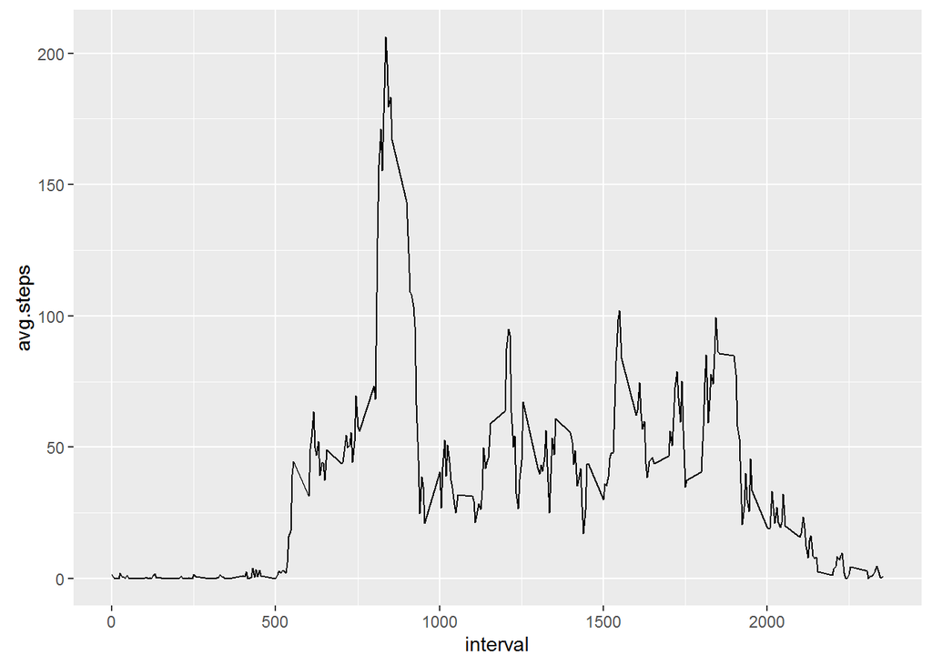

```r
ggplot(interval, aes(x = interval, y = avg.steps)) + geom_line()
```

2. Which 5-minute interval, on average across all the days in the dataset, contains the maximum number of steps?

```r
interval[which.max(interval$avg.steps),]
```

```
## # A tibble: 1 x 2
##   interval avg.steps
##      <int>     <dbl>
## 1      835  206.1698
```

## Imputing missing values

### Note that there are a number of days/intervals where there are missing values (coded as NA). The presence of missing days may introduce bias into some calculations or summaries of the data.

1. Calculate and report the total number of missing values in the dataset (i.e. the total number of rows with NAs)

```r
sum(is.na(activity$steps))
```

```
## [1] 2304
```

2. Devise a strategy for filling in all of the missing values in the dataset. The strategy does not need to be sophisticated. For example, you could use the mean/median for that day, or the mean for that 5-minute interval, etc.
3. Create a new dataset that is equal to the original dataset but with the missing data filled in.

```r
sum(is.na(activity$steps))
```

```
## [1] 2304
```

```r
activity2 <- activity
sum(is.na(activity2$steps))
```

```
## [1] 2304
```

```r
nas <- is.na(activity2$steps)
avg.interval <- tapply(X = activity2$steps, INDEX = activity2$interval, FUN = mean, simplify = T, na.rm = T)
avg.interval
```

```
##           0           5          10          15          20          25
##   1.7169811   0.3396226   0.1320755   0.1509434   0.0754717   2.0943396
##          30          35          40          45          50          55
##   0.5283019   0.8679245   0.0000000   1.4716981   0.3018868   0.1320755
##         100         105         110         115         120         125
##   0.3207547   0.6792453   0.1509434   0.3396226   0.0000000   1.1132075
##         130         135         140         145         150         155
##   1.8301887   0.1698113   0.1698113   0.3773585   0.2641509   0.0000000
##         200         205         210         215         220         225
##   0.0000000   0.0000000   1.1320755   0.0000000   0.0000000   0.1320755
##         230         235         240         245         250         255
##   0.0000000   0.2264151   0.0000000   0.0000000   1.5471698   0.9433962
##         300         305         310         315         320         325
##   0.0000000   0.0000000   0.0000000   0.0000000   0.2075472   0.6226415
##         330         335         340         345         350         355
##   1.6226415   0.5849057   0.4905660   0.0754717   0.0000000   0.0000000
##         400         405         410         415         420         425
##   1.1886792   0.9433962   2.5660377   0.0000000   0.3396226   0.3584906
##         430         435         440         445         450         455
##   4.1132075   0.6603774   3.4905660   0.8301887   3.1132075   1.1132075
##         500         505         510         515         520         525
##   0.0000000   1.5660377   3.0000000   2.2452830   3.3207547   2.9622642
##         530         535         540         545         550         555
##   2.0943396   6.0566038  16.0188679  18.3396226  39.4528302  44.4905660
##         600         605         610         615         620         625
##  31.4905660  49.2641509  53.7735849  63.4528302  49.9622642  47.0754717
##         630         635         640         645         650         655
##  52.1509434  39.3396226  44.0188679  44.1698113  37.3584906  49.0377358
##         700         705         710         715         720         725
##  43.8113208  44.3773585  50.5094340  54.5094340  49.9245283  50.9811321
##         730         735         740         745         750         755
##  55.6792453  44.3207547  52.2641509  69.5471698  57.8490566  56.1509434
##         800         805         810         815         820         825
##  73.3773585  68.2075472 129.4339623 157.5283019 171.1509434 155.3962264
##         830         835         840         845         850         855
## 177.3018868 206.1698113 195.9245283 179.5660377 183.3962264 167.0188679
##         900         905         910         915         920         925
## 143.4528302 124.0377358 109.1132075 108.1132075 103.7169811  95.9622642
##         930         935         940         945         950         955
##  66.2075472  45.2264151  24.7924528  38.7547170  34.9811321  21.0566038
```

[output cut: 41 more lines]

```
##  19.6226415  19.0188679  19.3396226  33.3396226  26.8113208  21.1698113
##        2030        2035        2040        2045        2050        2055
##  27.3018868  21.3396226  19.5471698  21.3207547  32.3018868  20.1509434
##        2100        2105        2110        2115        2120        2125
##  15.9433962  17.2264151  23.4528302  19.2452830  12.4528302   8.0188679
##        2130        2135        2140        2145        2150        2155
##  14.6603774  16.3018868   8.6792453   7.7924528   8.1320755   2.6226415
##        2200        2205        2210        2215        2220        2225
##   1.4528302   3.6792453   4.8113208   8.5094340   7.0754717   8.6981132
##        2230        2235        2240        2245        2250        2255
##   9.7547170   2.2075472   0.3207547   0.1132075   1.6037736   4.6037736
##        2300        2305        2310        2315        2320        2325
##   3.3018868   2.8490566   0.0000000   0.8301887   0.9622642   1.5849057
##        2330        2335        2340        2345        2350        2355
##   2.6037736   4.6981132   3.3018868   0.6415094   0.2264151   1.0754717
```

```r
activity2$steps[nas] <- avg.interval[as.character(activity2$interval[nas])]
names(activity2)
```

```
## [1] "steps"    "date"     "interval"
```

```r
sum(is.na(activity2$steps))
```

```
## [1] 0
```

```r
total.steps2 <- activity2 %>% group_by(date) %>% summarize(total.steps = sum(steps, na.rm = T))
total.steps2
```

```
## # A tibble: 61 x 2
##          date total.steps
##         <chr>       <dbl>
## 1  2012-10-01    10766.19
## 2  2012-10-02      126.00
## 3  2012-10-03    11352.00
## 4  2012-10-04    12116.00
## 5  2012-10-05    13294.00
## 6  2012-10-06    15420.00
## 7  2012-10-07    11015.00
## 8  2012-10-08    10766.19
## 9  2012-10-09    12811.00
## 10 2012-10-10     9900.00
## # ... with 51 more rows
```

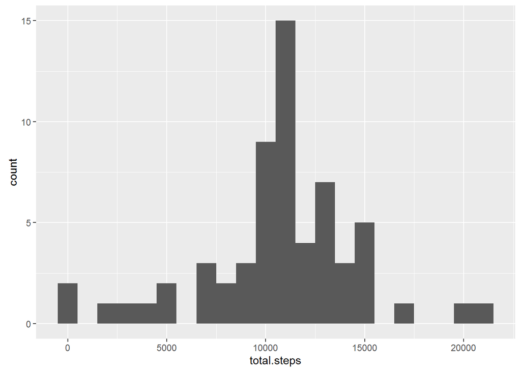

```r
ggplot(total.steps2, aes(x = total.steps)) + geom_histogram(binwidth = 1000)
```

```r
mean.steps.day2 <- aggregate(steps ~ date, data = activity2, FUN = mean)
median.steps.day2 <- aggregate(steps ~ date, data = activity2, FUN = median)
mean.steps.day2
```

```
##          date      steps
## 1  2012-10-01 37.3825996
## 2  2012-10-02  0.4375000
## 3  2012-10-03 39.4166667
## 4  2012-10-04 42.0694444
## 5  2012-10-05 46.1597222
## 6  2012-10-06 53.5416667
## 7  2012-10-07 38.2465278
## 8  2012-10-08 37.3825996
## 9  2012-10-09 44.4826389
## 10 2012-10-10 34.3750000
## 11 2012-10-11 35.7777778
## 12 2012-10-12 60.3541667
## 13 2012-10-13 43.1458333
## 14 2012-10-14 52.4236111
```

[output cut: 47 more lines]

```r
median.steps.day2
```

```
##          date    steps
## 1  2012-10-01 34.11321
## 2  2012-10-02  0.00000
## 3  2012-10-03  0.00000
## 4  2012-10-04  0.00000
## 5  2012-10-05  0.00000
## 6  2012-10-06  0.00000
## 7  2012-10-07  0.00000
## 8  2012-10-08 34.11321
## 9  2012-10-09  0.00000
## 10 2012-10-10  0.00000
## 11 2012-10-11  0.00000
## 12 2012-10-12  0.00000
## 13 2012-10-13  0.00000
## 14 2012-10-14  0.00000
```

[output cut: 47 more lines]

```r
#mean.steps2 <- mean(total.steps2$total.steps,na.rm = T)
#mean.steps2
```

## Are there differences in activity patterns between weekdays and weekends?

### For this part the weekdays() function may be of some help here. Use the dataset with the filled-in missing values for this part.

1. Create a new factor variable in the dataset with two levels – “weekday” and “weekend” indicating whether a given date is a weekday or weekend day.

```r
head(activity2)
```

```
##       steps       date interval
## 1 1.7169811 2012-10-01        0
## 2 0.3396226 2012-10-01        5
## 3 0.1320755 2012-10-01       10
## 4 0.1509434 2012-10-01       15
## 5 0.0754717 2012-10-01       20
## 6 2.0943396 2012-10-01       25
```

```r
activity2 <- activity2 %>% mutate(wk.typ = ifelse(weekdays(as.Date(activity2$date)) ==  "Saturday"|weekdays(as.Date(activity2$date)) == "Sunday", "weekend", "weekday"))

head(activity2)
```

```
##       steps       date interval  wk.typ
## 1 1.7169811 2012-10-01        0 weekday
## 2 0.3396226 2012-10-01        5 weekday
## 3 0.1320755 2012-10-01       10 weekday
## 4 0.1509434 2012-10-01       15 weekday
## 5 0.0754717 2012-10-01       20 weekday
## 6 2.0943396 2012-10-01       25 weekday
```

2. Make a panel plot containing a time series plot (i.e. type = “l”) of the 5-minute interval (x-axis) and the average number of steps taken, averaged across all weekday days or weekend days (y-axis). See the README file in the GitHub repository to see an example of what this plot should look like using simulated data.

```r
interval2 <- activity2 %>% group_by(interval, wk.typ) %>% summarize(avg.steps2 = mean(steps, na.rm = T))
head(interval2)
```

```
## Source: local data frame [6 x 3]
## Groups: interval [3]
##
##   interval  wk.typ avg.steps2
##      <int>   <chr>      <dbl>
## 1        0 weekday 2.25115304
## 2        0 weekend 0.21462264
## 3        5 weekday 0.44528302
## 4        5 weekend 0.04245283
## 5       10 weekday 0.17316562
## 6       10 weekend 0.01650943
```

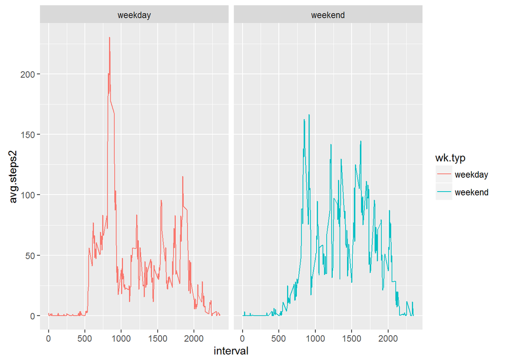

```r
ggplot(interval2, aes(x = interval, y = avg.steps2, color = wk.typ)) + geom_line() + facet_wrap(facets = ~ wk.typ)
```